# Manual Stylometry with R: Distances and Clustering

We will need three additional libraries for this tutorial:

- **tidyverse**: collection of packages that all share similar [*tidy*](https://www.tidyverse.org/) philosophy, data and grammar principles.
- **tidytext**: extension of tidy principles to text processing and analysis.
- **ggdendro**: extension of ggplot2 grammar of graphics to dendrogram.

## 0. Preparations

You can install packages one by one, using `install.packages("tidyverse")`. Or run code below, that checks for installed packages and installs if necessary.

```r
lapply(c("tidytext","tidyverse","ggdendro"),
       function(x) if(!is.element(x, installed.packages())) install.packages(x, dependencies = T))
```

Finally, load packages in R

```r
library(tidyverse)
library(tidytext)
library(ggdendro)
```

If you haven’t used `tidyverse` before, there are two things that will be important for this tutorial to understand:

1. **tidy data**: tidy workflow is designed around the idea of one-observation-per-row table, also sometimes called “long” tables. (We usually think in “long tables” when we create shopping lists. Each “row” there corresponds to one “observation”, or product that hold information also on -> quantity -> price)
2. **A pipe**. Tidyverse packages extensively use one special operator `%>%`, which is called *a pipe*. It *pipes* the output of previous function straight to the next one, saving us space and unnecessary temporary variables & cognitive overload when reading the code. Pipe is alternative to nesting: function `mean(c(1,5,10))` is identical to `c(1,5,10) %>% mean()`. Pipes linearly streamline your code and thinking.

## 1. Data

Let’s start with loading texts that we will use further for analysis. In our example few early 19th century English novels sit in the folder `corpus/`, which, in turn, sits in our working directory.

First, we list all files in the desired folder with their full relative path:

```r
files = list.files("corpus/",full.names = T)

files
```

```
## [1] "corpus//Austen_MansfieldPark_1814.txt"
## [2] "corpus//Austen_PrideandPrejudice_1813.txt"
## [3] "corpus//Austen_SenseandSensibility_1811.txt"
## [4] "corpus//Peacock_HeadlongHall_1815.txt"
## [5] "corpus//Peacock_MaidMarian_1821.txt"
## [6] "corpus//Peacock_NightmareAbbey_1818.txt"
## [7] "corpus//Scott_Ivanhoe_1820.txt"
## [8] "corpus//Scott_RobRoy_1817.txt"
## [9] "corpus//Scott_Waverley_1814.txt"
```

Then we use `tibble()` to assemble a table where filenames would serve as titles of our texts. The second column would hold **full texts** that were read from files using `read_files()`.

*Note: we use `sapply(files, read_files)` to apply `read_files()` function to each and every file that we have listed*

```r
corpus = tibble(title = files, # column title takes 9 filenames
                text = sapply(files, read_file)) %>% # column text takes 9 full texts
  mutate(title = str_replace(title, "corpus//(.*).txt", "\\1")) # NB. You will actually need only one backslash "/" if you're on Windows or Mac.

corpus
```

```
## # A tibble: 9 x 2
##   title                   text
##   <chr>                   <chr>
## 1 Austen_MansfieldPark_1… "MANSFIELD PARK\n\n\nCHAPTER I\n\nAbout thirty years …
## 2 Austen_PrideandPrejudi… "PRIDE AND PREJUDICE:\n\nA NOVEL.\n\nIN THREE VOLUMES…
## 3 Austen_SenseandSensibi… "SENSE AND SENSIBILITY\n\nby Jane Austen\n\n\nCHAPTER…
## 4 Peacock_HeadlongHall_1… "HEADLONG HALL\nby\nTHOMAS LOVE PEACOCK\n\nCHAPTER I\…
## 5 Peacock_MaidMarian_1821 "MAID MARIAN\n\n\nby Thomas Love Peacock\n\nMAID MARI…
## 6 Peacock_NightmareAbbey… "NIGHTMARE ABBEY\n\nBy\n\nThomas Love Peacock\n\nMATT…
## 7 Scott_Ivanhoe_1820      "IVANHOE\n\nA ROMANCE\n\n\nBy Sir Walter Scott\n\n\n …
## 8 Scott_RobRoy_1817       "ROB ROY\n\nBY SIR WALTER SCOTT\n\n\n\nROB ROY\n\n\n\…
## 9 Scott_Waverley_1814     "WAVERLEY\n\nOR 'T IS SIXTY YEARS SINCE\n\nUnder whic…
```

## 2. Word frequencies (word rank)

`tidytext` framework also follows one-observation-per-row princples. Which means: when you perform tokenization (splitting text to -whatever- units), you’ll end up with *very* long table that will include each of the tokens associated with a text on a separate row. Look at the example below

```r
corpus %>% #corpus table is piped further to unnest_tokens() function
  unnest_tokens(input=text, # input colum that will be splitted to tokens
                output=word, # name of the returning column
                token = "words") # words will be used as tokens
```

```
## # A tibble: 1,031,047 x 2
##    title                     word
##    <chr>                     <chr>
##  1 Austen_MansfieldPark_1814 mansfield
##  2 Austen_MansfieldPark_1814 park
##  3 Austen_MansfieldPark_1814 chapter
##  4 Austen_MansfieldPark_1814 i
##  5 Austen_MansfieldPark_1814 about
##  6 Austen_MansfieldPark_1814 thirty
##  7 Austen_MansfieldPark_1814 years
##  8 Austen_MansfieldPark_1814 ago
##  9 Austen_MansfieldPark_1814 miss
## 10 Austen_MansfieldPark_1814 maria
## # … with 1,031,037 more rows
```

Notice that resulting tibble has 1,031,047 rows, which effectively means that our corpus size is ~1m words.

We start at counting words *across* all corpus. We will need overall word frequency ranks to later use selected range of **Most Frequent Words (MFW)** for multivariate stylometry.

*Note: `count()` function does tranform the inital long table of tokens, giving word and it’s final count in the output*

```r
word_ranks = corpus %>%
  unnest_tokens(input=text, output=word, token="words") %>%
  count(word,sort=T) %>% # counts frequecy of each unique word in the long table + sorts by descending order
  mutate(rank = row_number()) %>% # separate column with a number of a row, which effectively tells us the rank of the word, because words were sorted beforehand
  select(-n) # we don't need counts here really

word_ranks
```

```
## # A tibble: 28,812 x 2
##    word   rank
##    <chr> <int>
##  1 the       1
##  2 of        2
##  3 and       3
##  4 to        4
##  5 a         5
##  6 in        6
##  7 i         7
##  8 his       8
##  9 was       9
## 10 that     10
## # … with 28,802 more rows
```

## 3. Word frequencies (in documents)

Now, having the information on word frequency ranks within the corpus we can proceed to count word frequencies inside each of our texts. Here we utilize `group_by()` function to define groups in the data upon which actions will be taken separately (so `count()` will act on tokens associated with specific text, as opposed to all tokens in the corpus).

```r
corpus %>%
  unnest_tokens(input = text, output = word, token = "words") %>%
  group_by(title) %>% # group by titles(=texts) here
  count(word)
```

```
## # A tibble: 78,057 x 3
## # Groups:   title [9]
##    title                     word        n
##    <chr>                     <chr>   <int>
##  1 Austen_MansfieldPark_1814 10          3
##  2 Austen_MansfieldPark_1814 14th        2
##  3 Austen_MansfieldPark_1814 20,000      1
##  4 Austen_MansfieldPark_1814 22nd        3
##  5 Austen_MansfieldPark_1814 23rd        1
##  6 Austen_MansfieldPark_1814 24th        1
##  7 Austen_MansfieldPark_1814 28th        1
##  8 Austen_MansfieldPark_1814 3rd         1
##  9 Austen_MansfieldPark_1814 a        3100
## 10 Austen_MansfieldPark_1814 abashed     1
## # … with 78,047 more rows
```

Next step would be getting *relative frequencies* of words, instead of absolute, i.e. what part each word takes from the overall size of the document? It is easy to do with `group_by()` and `mutate()`.

*Note: `mutate()` is aware of grouping, so your actions on variables will be taken independently in each group. Thus, calculating all counts via `sum(n)` will be done for each text, instead of the whole table.

```r
corpus %>%
  unnest_tokens(input = text, output = word, token = "words") %>%
  group_by(title) %>%
  count(word) %>%
  mutate(n = n/sum(n)) # each word count is divided to the sum of all counts within a text
```

```
## # A tibble: 78,057 x 3
## # Groups:   title [9]
##    title                     word             n
##    <chr>                     <chr>        <dbl>
##  1 Austen_MansfieldPark_1814 10      0.0000187
##  2 Austen_MansfieldPark_1814 14th    0.0000125
##  3 Austen_MansfieldPark_1814 20,000  0.00000623
##  4 Austen_MansfieldPark_1814 22nd    0.0000187
##  5 Austen_MansfieldPark_1814 23rd    0.00000623
##  6 Austen_MansfieldPark_1814 24th    0.00000623
##  7 Austen_MansfieldPark_1814 28th    0.00000623
##  8 Austen_MansfieldPark_1814 3rd     0.00000623
##  9 Austen_MansfieldPark_1814 a       0.0193
## 10 Austen_MansfieldPark_1814 abashed 0.00000623
## # … with 78,047 more rows
```

It is important to know the position of the each word in the frequency rank. We can *join* data from previously determined `word_ranks` to our frequency table using `left_join()` function. For each match in the reference column (in our case it is `word`), it will join corresponding values from the second table:

```r
frequencies_long = corpus %>%
  unnest_tokens(input = text, output = word, token = "words") %>%
  group_by(title) %>%
  count(word) %>%
  mutate(n = n/sum(n)) %>%
  left_join(word_ranks, by="word") %>%  # we are joining two tables by words, so for each match between two tables corresponding values are added to our main table
  arrange(rank) # now table can be arranged by ranks

frequencies_long
```

```
## # A tibble: 78,057 x 4
## # Groups:   title [9]
##    title                           word       n  rank
##    <chr>                           <chr>  <dbl> <int>
##  1 Austen_MansfieldPark_1814       the   0.0387     1
##  2 Austen_PrideandPrejudice_1813   the   0.0354     1
##  3 Austen_SenseandSensibility_1811 the   0.0342     1
##  4 Peacock_HeadlongHall_1815       the   0.0738     1
##  5 Peacock_MaidMarian_1821         the   0.0719     1
##  6 Peacock_NightmareAbbey_1818     the   0.0585     1
##  7 Scott_Ivanhoe_1820              the   0.0698     1
##  8 Scott_RobRoy_1817               the   0.0543     1
##  9 Scott_Waverley_1814             the   0.0664     1
## 10 Austen_MansfieldPark_1814       of    0.0298     2
## # … with 78,047 more rows
```

## 3. Document-Term matrix

Many methods of text analysis operate on specific type of data - so-called *document-term matrix* (or DTM). It’s an opposite of the “long” table we’ve got so far: in DTM each document is expressed as one row of numbers (word frequencies) and each column corresponds to a word. In “tidy” table we have each row is one word with associated data.

There are few ways to transform “long” table to “wide” matrix with rows being vectors of numbers that describe specific documents. One of them is `spread()` that will let you continue working with a “wide” tibble, but will mess with your table structure. Second is `cast_dtm()` which directly transforms data to a dtm-like object.

### spread()

Using `spread()` to build DTM is a bit tedious, because when you transform words to columns, it will arrange columns alphabetically. We need to have control over most frequent words, so we need them to be arranged by rank. Getting to that point might prove confusing.

### cast_dtm()

So forget it. Since we are going for the matrix format anyways, it will be more convenient to use `cast_dtm()` and it will preserve our arrangement of the table by ranks:

```r
dtm = frequencies_long %>%
  cast_dtm(document = title, term = word, value = n) %>%
  as.matrix()
```

Let’s render first 10 columns of the resulting matrix:

|  | the | of | and | to | a | in | i | his | was | that |
| --- | --- | --- | --- | --- | --- | --- | --- | --- | --- | --- |
| Austen_MansfieldPark_1814 | 0.039 | 0.030 | 0.034 | 0.034 | 0.019 | 0.016 | 0.015 | 0.008 | 0.017 | 0.010 |
| Austen_PrideandPrejudice_1813 | 0.035 | 0.030 | 0.029 | 0.034 | 0.016 | 0.015 | 0.017 | 0.010 | 0.015 | 0.013 |
| Austen_SenseandSensibility_1811 | 0.034 | 0.030 | 0.029 | 0.034 | 0.017 | 0.016 | 0.017 | 0.009 | 0.016 | 0.012 |
| Peacock_HeadlongHall_1815 | 0.074 | 0.049 | 0.032 | 0.025 | 0.025 | 0.018 | 0.009 | 0.010 | 0.008 | 0.011 |
| Peacock_MaidMarian_1821 | 0.072 | 0.035 | 0.041 | 0.024 | 0.022 | 0.018 | 0.011 | 0.015 | 0.007 | 0.010 |
| Peacock_NightmareAbbey_1818 | 0.058 | 0.039 | 0.036 | 0.023 | 0.024 | 0.020 | 0.014 | 0.011 | 0.010 | 0.011 |
| Scott_Ivanhoe_1820 | 0.070 | 0.041 | 0.032 | 0.028 | 0.019 | 0.014 | 0.011 | 0.014 | 0.008 | 0.009 |
| Scott_RobRoy_1817 | 0.054 | 0.033 | 0.033 | 0.030 | 0.022 | 0.016 | 0.023 | 0.011 | 0.010 | 0.011 |
| Scott_Waverley_1814 | 0.066 | 0.041 | 0.032 | 0.029 | 0.023 | 0.017 | 0.008 | 0.017 | 0.011 | 0.010 |

### Z-transformation

Many efficient distance measures in stylometry are based not on the relative frequencies, but on the **z-scores**: a value that shows how much a given word deviates from the mean usage of this word across whole corpus (expressed in standard deviations). We can use `scale()` on our matrix to calculate it effortlesly:

```r
dtm_z = dtm %>%
  scale()
```

Now our values in matrix express deviations of words in a document from the mean:

|  | the | of | and | to | a | in | i | his | was | that |
| --- | --- | --- | --- | --- | --- | --- | --- | --- | --- | --- |
| Austen_MansfieldPark_1814 | -1.067 | -0.975 | 0.168 | 1.140 | -0.471 | -0.628 | 0.189 | -1.153 | 1.475 | -0.271 |
| Austen_PrideandPrejudice_1813 | -1.273 | -1.002 | -1.050 | 1.095 | -1.626 | -0.808 | 0.652 | -0.481 | 1.055 | 1.875 |
| Austen_SenseandSensibility_1811 | -1.345 | -0.975 | -1.092 | 1.177 | -1.097 | -0.168 | 0.594 | -1.127 | 1.181 | 0.635 |
| Peacock_HeadlongHall_1815 | 1.111 | 1.911 | -0.421 | -0.926 | 1.337 | 0.715 | -1.008 | -0.563 | -1.029 | 0.584 |
| Peacock_MaidMarian_1821 | 0.992 | -0.147 | 2.143 | -1.155 | 0.367 | 0.507 | -0.614 | 0.998 | -1.060 | -0.985 |
| Peacock_NightmareAbbey_1818 | 0.161 | 0.353 | 0.839 | -1.349 | 1.022 | 1.964 | 0.010 | -0.111 | -0.378 | -0.199 |
| Scott_Ivanhoe_1820 | 0.864 | 0.652 | -0.270 | -0.188 | -0.586 | -1.481 | -0.572 | 0.923 | -0.939 | -1.490 |
| Scott_RobRoy_1817 | -0.097 | -0.561 | 0.040 | 0.260 | 0.346 | -0.276 | 1.985 | -0.204 | -0.332 | 0.386 |
| Scott_Waverley_1814 | 0.655 | 0.745 | -0.357 | -0.055 | 0.709 | 0.175 | -1.236 | 1.718 | 0.026 | -0.535 |

If we wanted, we could have calculated z-scores within our long table manually:

```r
dtm_z = frequencies_long %>%
  group_by(word) %>% # group words here!
  mutate(z_score = (n-mean(n))/sd(n)) %>% # frequency of a word minus mean frequency of a word divided by standard deviation of a word
  cast_dtm(document = title, term=word, value=z_score) %>%
  as.matrix()
```

Which will result in the same matrix:

|  | the | of | and | to | a | in | i | his | was | that |
| --- | --- | --- | --- | --- | --- | --- | --- | --- | --- | --- |
| Austen_MansfieldPark_1814 | -1.067 | -0.975 | 0.168 | 1.140 | -0.471 | -0.628 | 0.189 | -1.153 | 1.475 | -0.271 |
| Austen_PrideandPrejudice_1813 | -1.273 | -1.002 | -1.050 | 1.095 | -1.626 | -0.808 | 0.652 | -0.481 | 1.055 | 1.875 |
| Austen_SenseandSensibility_1811 | -1.345 | -0.975 | -1.092 | 1.177 | -1.097 | -0.168 | 0.594 | -1.127 | 1.181 | 0.635 |
| Peacock_HeadlongHall_1815 | 1.111 | 1.911 | -0.421 | -0.926 | 1.337 | 0.715 | -1.008 | -0.563 | -1.029 | 0.584 |
| Peacock_MaidMarian_1821 | 0.992 | -0.147 | 2.143 | -1.155 | 0.367 | 0.507 | -0.614 | 0.998 | -1.060 | -0.985 |
| Peacock_NightmareAbbey_1818 | 0.161 | 0.353 | 0.839 | -1.349 | 1.022 | 1.964 | 0.010 | -0.111 | -0.378 | -0.199 |
| Scott_Ivanhoe_1820 | 0.864 | 0.652 | -0.270 | -0.188 | -0.586 | -1.481 | -0.572 | 0.923 | -0.939 | -1.490 |
| Scott_RobRoy_1817 | -0.097 | -0.561 | 0.040 | 0.260 | 0.346 | -0.276 | 1.985 | -0.204 | -0.332 | 0.386 |
| Scott_Waverley_1814 | 0.655 | 0.745 | -0.357 | -0.055 | 0.709 | 0.175 | -1.236 | 1.718 | 0.026 | -0.535 |

## 4. Classic Delta distance

When we do have a proper matrix, it’s easy in R to calculate distances between each text (represented as vector of word frequencies in our case) to each other text - using `dist()` function. First we need to determine the amount of most frequent words we will be using for this operation. Let’s say, we set MFW to 200. It’s fairly straightforward now to subset our matrix, taking only 200 first columns, since we know they are arranged by the word overall frequency rank.  
Since Burrow’s Delta is a Manhattan distance, calculated using z-scores and divided by number of features used (so by n MFW), we can express everything as follows:

```r
mfw = 200
delta = dist(dtm_z[,1:mfw], method="manhattan")/mfw
```

`dist()` returns a square matrix of mutual distances between all texts : (column names are cut to fit the table)

|  | Au..1814 | Au..1813 | Au..1811 | Pe..1815 | Pe..1821 | Pe..1818 | Sc..1820 | Sc..1817 | Sc..1814 |
| --- | --- | --- | --- | --- | --- | --- | --- | --- | --- |
| Austen_MansfieldPark_1814 | 0.000 | 0.687 | 0.654 | 1.399 | 1.435 | 1.226 | 1.491 | 1.242 | 1.300 |
| Austen_PrideandPrejudice_1813 | 0.687 | 0.000 | 0.563 | 1.436 | 1.360 | 1.242 | 1.416 | 1.206 | 1.318 |
| Austen_SenseandSensibility_1811 | 0.654 | 0.563 | 0.000 | 1.486 | 1.488 | 1.300 | 1.491 | 1.277 | 1.304 |
| Peacock_HeadlongHall_1815 | 1.399 | 1.436 | 1.486 | 0.000 | 1.006 | 0.905 | 1.074 | 0.997 | 0.857 |
| Peacock_MaidMarian_1821 | 1.435 | 1.360 | 1.488 | 1.006 | 0.000 | 1.030 | 0.900 | 0.980 | 0.966 |
| Peacock_NightmareAbbey_1818 | 1.226 | 1.242 | 1.300 | 0.905 | 1.030 | 0.000 | 1.174 | 0.972 | 0.994 |
| Scott_Ivanhoe_1820 | 1.491 | 1.416 | 1.491 | 1.074 | 0.900 | 1.174 | 0.000 | 0.849 | 0.767 |
| Scott_RobRoy_1817 | 1.242 | 1.206 | 1.277 | 0.997 | 0.980 | 0.972 | 0.849 | 0.000 | 0.671 |
| Scott_Waverley_1814 | 1.300 | 1.318 | 1.304 | 0.857 | 0.966 | 0.994 | 0.767 | 0.671 | 0.000 |

It’s not that easy to read this table and be aware of the many relationships between texts (although, it’s evident that the closest neighbours of *Mansfield Park* are other novels by Austen). To get further insight into the results, hiearchical clustering is performed and relations between entities are drawn as clusters on dendrogram.

## 5. Hierarchical clustering

To perform clustering we need a ‘distance’ object, the immediate ouput of `dist()` function. You can also render any square matrix with pairwise distances as such using `as.dist()`.

```r
clusters = delta %>%
  hclust(method = "ward.D2") %>% # performs hierarchical clustering with Ward's method, returns cluster info
  as.dendrogram() # renders object as dendrogram
```

There is fast way to get to the final tree, if you don’t want customization to kick in: `ggdendrogram()`

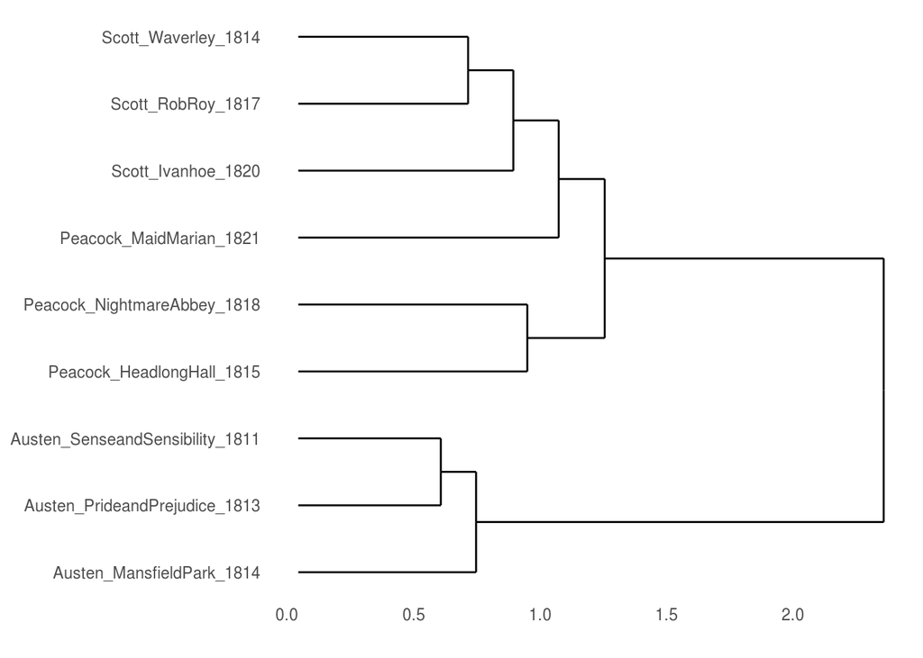

```r
ggdendrogram(clusters,rotate=T)
```

Clusters are self-evident with some unfortunate behaviour of one Peacock’s novel. Now, to add some flavour to this tree, we might consider working more closely to `ggdendro` package.  
First, transform clusters to tidy object.

```r
ggclust = dendro_data(clusters)
```

Variable `ggclust` now contains information of “segments” (branches of the tree) and labels/leaves (tips of the tree)

```r
ggclust$labels
```

```
##   x y                           label
## 1 1 0       Austen_MansfieldPark_1814
## 2 2 0   Austen_PrideandPrejudice_1813
## 3 3 0 Austen_SenseandSensibility_1811
## 4 4 0       Peacock_HeadlongHall_1815
## 5 5 0     Peacock_NightmareAbbey_1818
## 6 6 0         Peacock_MaidMarian_1821
## 7 7 0              Scott_Ivanhoe_1820
## 8 8 0               Scott_RobRoy_1817
## 9 9 0             Scott_Waverley_1814
```

We can freely modify it to make specific classes that would be used later for various purposes. If I would want to color labels by author name, it would be necessary to extract it:

```r
ggclust$labels = ggclust$labels %>%
  separate(label, c("author", "title", "year"), sep="_") %>% #split label to various parts
  mutate(label = paste(author, title, year, sep="_")) #reconstruct original label again!

ggclust$labels
```

```
##   x y  author               title year                           label
## 1 1 0  Austen       MansfieldPark 1814       Austen_MansfieldPark_1814
## 2 2 0  Austen   PrideandPrejudice 1813   Austen_PrideandPrejudice_1813
## 3 3 0  Austen SenseandSensibility 1811 Austen_SenseandSensibility_1811
## 4 4 0 Peacock        HeadlongHall 1815       Peacock_HeadlongHall_1815
## 5 5 0 Peacock      NightmareAbbey 1818     Peacock_NightmareAbbey_1818
## 6 6 0 Peacock          MaidMarian 1821         Peacock_MaidMarian_1821
## 7 7 0   Scott             Ivanhoe 1820              Scott_Ivanhoe_1820
## 8 8 0   Scott              RobRoy 1817               Scott_RobRoy_1817
## 9 9 0   Scott            Waverley 1814             Scott_Waverley_1814
```

Now we just need to plot segments and labels using ggplot2’s grammar of graphics! Don’t worry, it looks scarier than it really is.

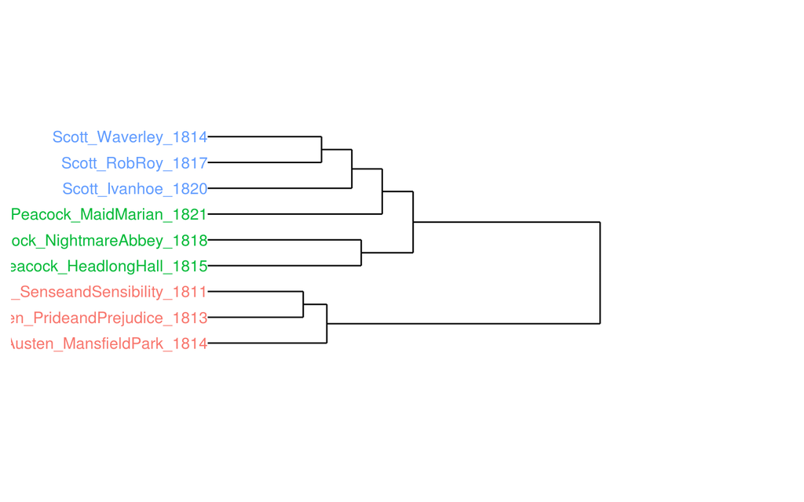

```r
ggplot() +
  # plot segments
  geom_segment(data=ggclust$segments,aes(x,y,xend=xend, yend=yend)) +
  # plot leaves
  geom_text(data=ggclust$labels, aes(x,y,label=label, color=author), hjust=1, angle=0, size=4) +
  coord_flip() +
  scale_y_continuous(expand=c(0.5, 0)) +
  scale_x_continuous(expand=c(0.5, 1)) +
  theme_dendro() +
  guides(color=F)
```